# HW R

廖振博

2020/5/1

### R homework

#### This is my homework to summary the R language that I have learned.

## **判斷變數所屬類別**

#### 在分析資料前必須知道變數是屬於numeric還是logical，因此使用class來判斷變數所屬類別。

#### 例如:

```r
class(c(TRUE,FALSE))
```

```
## [1] "logical"
```

```r
class(3.14)
```

```
## [1] "numeric"
```

## **變數轉型**

#### 我們已經知道變數的類別後，當有些統計方法需要變數是類別或是數值時，需要將變數轉型成我們需要的變數型態

```r
x<-3.14
as.numeric(x)
```

```
## [1] 3.14
```

```r
y<-c(11,22,33,44)
as.data.frame(y)
```

```
##    y
## 1 11
## 2 22
## 3 33
## 4 44
```

## **檢視變數基本統計量**

#### summary這個函數可以幫助我們了解資料的分布狀況，甚至是統計模型配適的狀況與檢驗

```r
summary(attitude)
```

```
##      rating        complaints     privileges       learning         raises
##  Min.   :40.00   Min.   :37.0   Min.   :30.00   Min.   :34.00   Min.   :43.00
##  1st Qu.:58.75   1st Qu.:58.5   1st Qu.:45.00   1st Qu.:47.00   1st Qu.:58.25
##  Median :65.50   Median :65.0   Median :51.50   Median :56.50   Median :63.50
##  Mean   :64.63   Mean   :66.6   Mean   :53.13   Mean   :56.37   Mean   :64.63
##  3rd Qu.:71.75   3rd Qu.:77.0   3rd Qu.:62.50   3rd Qu.:66.75   3rd Qu.:71.00
##  Max.   :85.00   Max.   :90.0   Max.   :83.00   Max.   :75.00   Max.   :88.00
##     critical        advance
##  Min.   :49.00   Min.   :25.00
##  1st Qu.:69.25   1st Qu.:35.00
##  Median :77.50   Median :41.00
##  Mean   :74.77   Mean   :42.93
##  3rd Qu.:80.00   3rd Qu.:47.75
##  Max.   :92.00   Max.   :72.00
```

```r
fit1 <- lm(rating ~ ., data = attitude)
summary(fit1)
```

```
##
## Call:
## lm(formula = rating ~ ., data = attitude)
##
## Residuals:
##      Min       1Q   Median       3Q      Max
## -10.9418  -4.3555   0.3158   5.5425  11.5990
##
## Coefficients:
##             Estimate Std. Error t value Pr(>|t|)
## (Intercept) 10.78708   11.58926   0.931 0.361634
## complaints   0.61319    0.16098   3.809 0.000903 ***
## privileges  -0.07305    0.13572  -0.538 0.595594
## learning     0.32033    0.16852   1.901 0.069925 .
## raises       0.08173    0.22148   0.369 0.715480
## critical     0.03838    0.14700   0.261 0.796334
## advance     -0.21706    0.17821  -1.218 0.235577
## ---
## Signif. codes:  0 '***' 0.001 '**' 0.01 '*' 0.05 '.' 0.1 ' ' 1
##
## Residual standard error: 7.068 on 23 degrees of freedom
## Multiple R-squared:  0.7326, Adjusted R-squared:  0.6628
## F-statistic:  10.5 on 6 and 23 DF,  p-value: 1.24e-05
```

#### str這個函數也能用來檢視變數資料結構，還能顯示變數類型以及開頭的幾個值

```r
str(attitude)
```

```
## 'data.frame':    30 obs. of  7 variables:
##  $ rating    : num  43 63 71 61 81 43 58 71 72 67 ...
##  $ complaints: num  51 64 70 63 78 55 67 75 82 61 ...
##  $ privileges: num  30 51 68 45 56 49 42 50 72 45 ...
##  $ learning  : num  39 54 69 47 66 44 56 55 67 47 ...
##  $ raises    : num  61 63 76 54 71 54 66 70 71 62 ...
##  $ critical  : num  92 73 86 84 83 49 68 66 83 80 ...
##  $ advance   : num  45 47 48 35 47 34 35 41 31 41 ...
```

## **找遺失值**

```r
z<-c(1:3,NA)
z
```

```
## [1]  1  2  3 NA
```

```r
is.na(z)
```

```
## [1] FALSE FALSE FALSE  TRUE
```

## **建立矩陣**

```r
matrix(1:6,nrow = 2,ncol = 3)
```

```
##      [,1] [,2] [,3]
## [1,]    1    3    5
## [2,]    2    4    6
```

#### dimnames 可指定參數名稱

```r
matrix(1:6,nrow = 2,ncol = 3,dimnames = list(c('r1','r2'),c('c1','c2','c3')))
```

```
##    c1 c2 c3
## r1  1  3  5
## r2  2  4  6
```

## **合併矩陣**

#### 假設有兩個矩陣

```r
x<-matrix(1:6, nrow = 3, ncol = 2)
y<-matrix(11:16, nrow = 3, ncol = 2)
x
```

```
##      [,1] [,2]
## [1,]    1    4
## [2,]    2    5
## [3,]    3    6
```

```r
y
```

```
##      [,1] [,2]
## [1,]   11   14
## [2,]   12   15
## [3,]   13   16
```

#### 使用C函數合併兩矩陣，會將資料轉為一維矩陣

```r
c(x,y)
```

```
##  [1]  1  2  3  4  5  6 11 12 13 14 15 16
```

#### cbind與rbind會保持資料結構合併

```r
cbind(x,y)
```

```
##      [,1] [,2] [,3] [,4]
## [1,]    1    4   11   14
## [2,]    2    5   12   15
## [3,]    3    6   13   16
```

```r
rbind(x,y)
```

```
##      [,1] [,2]
## [1,]    1    4
## [2,]    2    5
## [3,]    3    6
## [4,]   11   14
## [5,]   12   15
## [6,]   13   16
```

## **建立data frame**

#### data frame與矩陣類似，不過他每一行間的資料類型是可以不同的

```r
k<- data.frame(x = letters[1:6],y = rnorm(6),z = runif(6) > 0.5)
k
```

```
##   x          y     z
## 1 a -1.1415788  TRUE
## 2 b -0.1651438  TRUE
## 3 c -1.7512855  TRUE
## 4 d -1.2753795 FALSE
## 5 e -0.7117860  TRUE
## 6 f -0.6226931  TRUE
```

#### row.names 可指定data frame的列名稱

```r
data.frame(x = letters[1:6],y = rnorm(6),z = runif(6) > 0.5,row.names = c("A", "B", "C", "D", "E","F"))
```

```
##   x          y     z
## A a  1.3558110 FALSE
## B b -0.5456697 FALSE
## C c  0.3483594  TRUE
## D d  0.5092813  TRUE
## E e -0.1294622  TRUE
## F f  0.7890985  TRUE
```

## **Linear Model**

#### 接下來想簡單整理一些迴歸分析的codes，先以R的內建資料集attitude作範例

#### 先以散布圖觀察各變數間的關係，以及summary觀察資料結構

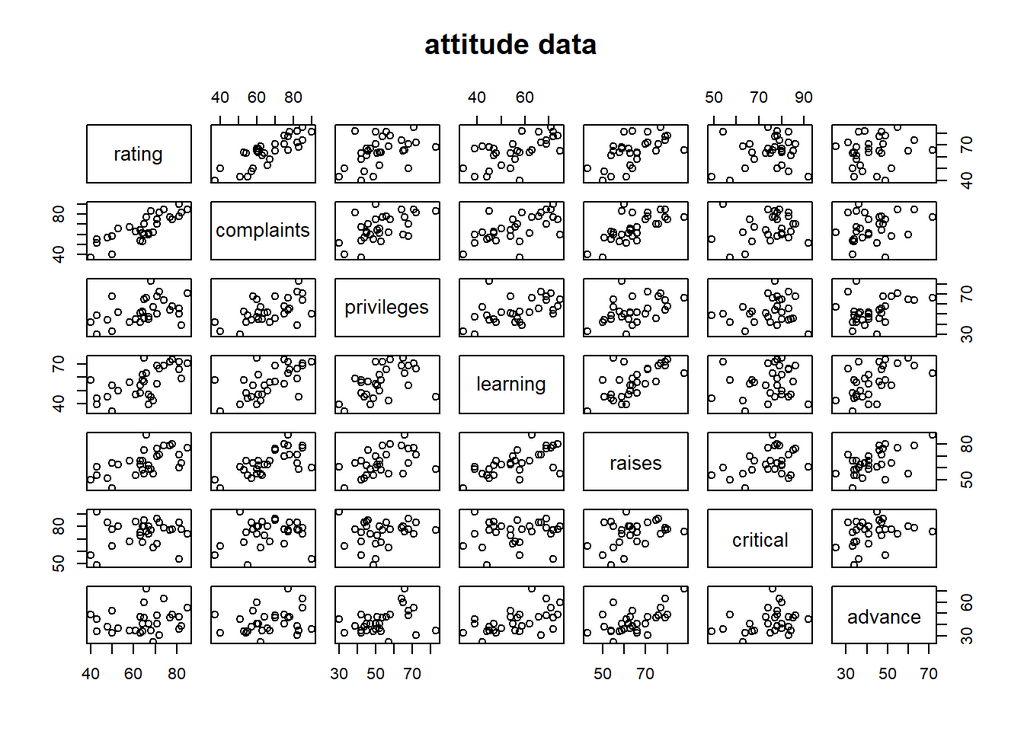

```r
pairs(attitude,main="attitude data")
```

```r
summary(attitude)
```

```
##      rating        complaints     privileges       learning         raises
##  Min.   :40.00   Min.   :37.0   Min.   :30.00   Min.   :34.00   Min.   :43.00
##  1st Qu.:58.75   1st Qu.:58.5   1st Qu.:45.00   1st Qu.:47.00   1st Qu.:58.25
##  Median :65.50   Median :65.0   Median :51.50   Median :56.50   Median :63.50
##  Mean   :64.63   Mean   :66.6   Mean   :53.13   Mean   :56.37   Mean   :64.63
##  3rd Qu.:71.75   3rd Qu.:77.0   3rd Qu.:62.50   3rd Qu.:66.75   3rd Qu.:71.00
##  Max.   :85.00   Max.   :90.0   Max.   :83.00   Max.   :75.00   Max.   :88.00
##     critical        advance
##  Min.   :49.00   Min.   :25.00
##  1st Qu.:69.25   1st Qu.:35.00
##  Median :77.50   Median :41.00
##  Mean   :74.77   Mean   :42.93
##  3rd Qu.:80.00   3rd Qu.:47.75
##  Max.   :92.00   Max.   :72.00
```

#### 以lm函數配適迴歸模型，函數中要陳述資料集與想加入模型的變數

#### 以下~.表將資料集中所有變數都加入模型中

```r
fit1 <- lm(rating ~ ., data = attitude)
summary(fit1)
```

```
##
## Call:
## lm(formula = rating ~ ., data = attitude)
##
## Residuals:
##      Min       1Q   Median       3Q      Max
## -10.9418  -4.3555   0.3158   5.5425  11.5990
##
## Coefficients:
##             Estimate Std. Error t value Pr(>|t|)
## (Intercept) 10.78708   11.58926   0.931 0.361634
## complaints   0.61319    0.16098   3.809 0.000903 ***
## privileges  -0.07305    0.13572  -0.538 0.595594
## learning     0.32033    0.16852   1.901 0.069925 .
## raises       0.08173    0.22148   0.369 0.715480
## critical     0.03838    0.14700   0.261 0.796334
## advance     -0.21706    0.17821  -1.218 0.235577
## ---
## Signif. codes:  0 '***' 0.001 '**' 0.01 '*' 0.05 '.' 0.1 ' ' 1
##
## Residual standard error: 7.068 on 23 degrees of freedom
## Multiple R-squared:  0.7326, Adjusted R-squared:  0.6628
## F-statistic:  10.5 on 6 and 23 DF,  p-value: 1.24e-05
```

#### 由summary這個函數的結果告訴我們只有complaints的效應是顯著的

#### 因此在更進一步的模型變數選擇中，就會比較重視complaints這個變數

#### 而模型配適中還有一個重要的一點，就是model checking，如constant variance、normality等等

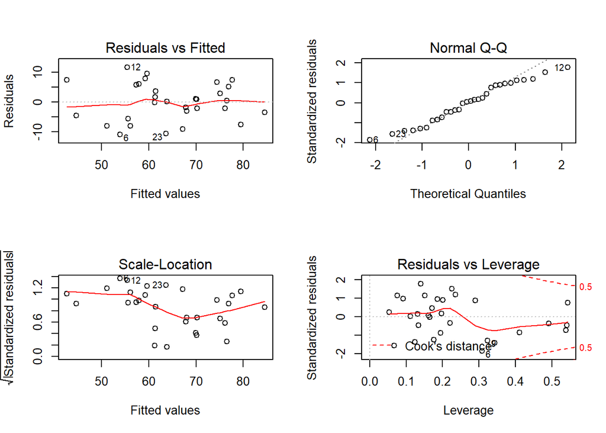

```r
opar <- par(mfrow = c(2, 2))
plot(fit1)
```

#### 另外還可以使用統計方法幫我們選擇重要的變數，例如Stepwise regression

#### pent所代表的是將變數選進模型的p-value標準，而prem則是淘汰變數的p-value標準

```r
fit1 <- lm(rating ~ ., data = attitude)
# Forward
stepwise.for <- ols_step_forward_p(fit1, pent = 0.15)
summary(stepwise.for$model)
```

```
##
## Call:
## lm(formula = paste(response, "~", paste(preds, collapse = " + ")),
##     data = l)
##
## Residuals:
##      Min       1Q   Median       3Q      Max
## -11.5568  -5.7331   0.6701   6.5341  10.3610
##
## Coefficients:
##             Estimate Std. Error t value Pr(>|t|)
## (Intercept)   9.8709     7.0612   1.398    0.174
## complaints    0.6435     0.1185   5.432 9.57e-06 ***
## learning      0.2112     0.1344   1.571    0.128
## ---
## Signif. codes:  0 '***' 0.001 '**' 0.01 '*' 0.05 '.' 0.1 ' ' 1
##
## Residual standard error: 6.817 on 27 degrees of freedom
## Multiple R-squared:  0.708,  Adjusted R-squared:  0.6864
## F-statistic: 32.74 on 2 and 27 DF,  p-value: 6.058e-08
```

```r
# Backward
stepwise.back <- ols_step_backward_p(fit1, prem = 0.15)
summary(stepwise.back$model)
```

```
##
## Call:
## lm(formula = paste(response, "~", paste(preds, collapse = " + ")),
##     data = l)
##
## Residuals:
##      Min       1Q   Median       3Q      Max
## -11.5568  -5.7331   0.6701   6.5341  10.3610
##
## Coefficients:
##             Estimate Std. Error t value Pr(>|t|)
## (Intercept)   9.8709     7.0612   1.398    0.174
## complaints    0.6435     0.1185   5.432 9.57e-06 ***
## learning      0.2112     0.1344   1.571    0.128
## ---
## Signif. codes:  0 '***' 0.001 '**' 0.01 '*' 0.05 '.' 0.1 ' ' 1
##
## Residual standard error: 6.817 on 27 degrees of freedom
## Multiple R-squared:  0.708,  Adjusted R-squared:  0.6864
## F-statistic: 32.74 on 2 and 27 DF,  p-value: 6.058e-08
```

```r
# Both
stepwise.both <- ols_step_both_p(fit1, pent = 0.15, prem = 0.15)
summary(stepwise.both$model)
```

```
##
## Call:
## lm(formula = paste(response, "~", paste(preds, collapse = " + ")),
##     data = l)
##
## Residuals:
##      Min       1Q   Median       3Q      Max
## -11.5568  -5.7331   0.6701   6.5341  10.3610
##
## Coefficients:
##             Estimate Std. Error t value Pr(>|t|)
## (Intercept)   9.8709     7.0612   1.398    0.174
## complaints    0.6435     0.1185   5.432 9.57e-06 ***
## learning      0.2112     0.1344   1.571    0.128
## ---
## Signif. codes:  0 '***' 0.001 '**' 0.01 '*' 0.05 '.' 0.1 ' ' 1
##
## Residual standard error: 6.817 on 27 degrees of freedom
## Multiple R-squared:  0.708,  Adjusted R-squared:  0.6864
## F-statistic: 32.74 on 2 and 27 DF,  p-value: 6.058e-08
```

## **CRD實驗**

```r
CRD.data <- matrix(rep(NA, 20*2), 20, 2)
CRD.data <- data.frame(CRD.data)
colnames(CRD.data) <- c("treatments", "response")
CRD.data$response <- c(575, 542, 530, 539, 570,
                       565, 593, 590, 579, 610,
                       600, 651, 610, 637, 629,
                       725, 700, 715, 685, 710)
levels <- as.factor(c(rep(160, 5), rep(180, 5), rep(200, 5), rep(220, 5)))
CRD.data$treatments <- levels
CRD.fit1 <- lm(response ~ treatments, data = CRD.data)
summary(CRD.fit1)
```

```
##
## Call:
## lm(formula = response ~ treatments, data = CRD.data)
##
## Residuals:
##    Min     1Q Median     3Q    Max
##  -25.4  -13.0    2.8   13.2   25.6
##
## Coefficients:
##               Estimate Std. Error t value Pr(>|t|)
## (Intercept)    551.200      8.169  67.471  < 2e-16 ***
## treatments180   36.200     11.553   3.133  0.00642 **
## treatments200   74.200     11.553   6.422 8.44e-06 ***
## treatments220  155.800     11.553  13.485 3.73e-10 ***
## ---
## Signif. codes:  0 '***' 0.001 '**' 0.01 '*' 0.05 '.' 0.1 ' ' 1
##
## Residual standard error: 18.27 on 16 degrees of freedom
## Multiple R-squared:  0.9261, Adjusted R-squared:  0.9122
## F-statistic:  66.8 on 3 and 16 DF,  p-value: 2.883e-09
```

#### Model checking by graph

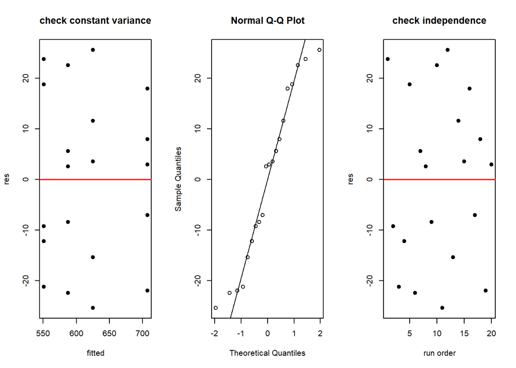

```r
par(mfrow = c(1, 3))
plot(CRD.fit1$fitted.values, CRD.fit1$residuals, pch = 19,xlab = "fitted", ylab = "res")
lines(c(0, 1000), c(0, 0), col = 2, lwd = 1.5)
title("check constant variance")
qqnorm(CRD.fit1$residuals)
qqline(CRD.fit1$residuals)
plot(CRD.fit1$residuals, pch = 19, xlab = "run order", ylab = "res")
lines(c(0, 1000), c(0, 0), col = 2, lwd = 1.5)
title("check independence")
```

## **2^(4-1)design**

```r
design1 <- FrF2(8, generators = "ABC", randomize=FALSE)
y <- c(45, 100, 45, 65, 75, 60, 80, 96)
design1 <- add.response(design1, y)
design1$A <- (as.numeric(design1$A)-(1.5))/(0.5)
design1$B <- (as.numeric(design1$B)-(1.5))/(0.5)
design1$C <- (as.numeric(design1$C)-(1.5))/(0.5)
design1$D <- (as.numeric(design1$D)-(1.5))/(0.5)
fit1 <- lm(y ~ A+B+C+D+A*B+A*C+A*D, data = design1)
summary(fit1)
```

```
##
## Call:
## lm.default(formula = y ~ A + B + C + D + A * B + A * C + A *
##     D, data = design1)
##
## Residuals:
## ALL 8 residuals are 0: no residual degrees of freedom!
##
## Coefficients:
##             Estimate Std. Error t value Pr(>|t|)
## (Intercept)    70.75         NA      NA       NA
## A               9.50         NA      NA       NA
## B               0.75         NA      NA       NA
## C               7.00         NA      NA       NA
## D               8.25         NA      NA       NA
## A:B            -0.50         NA      NA       NA
## A:C            -9.25         NA      NA       NA
## A:D             9.50         NA      NA       NA
##
## Residual standard error: NaN on 0 degrees of freedom
## Multiple R-squared:      1,  Adjusted R-squared:    NaN
## F-statistic:   NaN on 7 and 0 DF,  p-value: NA
```

#### LenthPlot可以幫助我們了解那些effects比較顯著

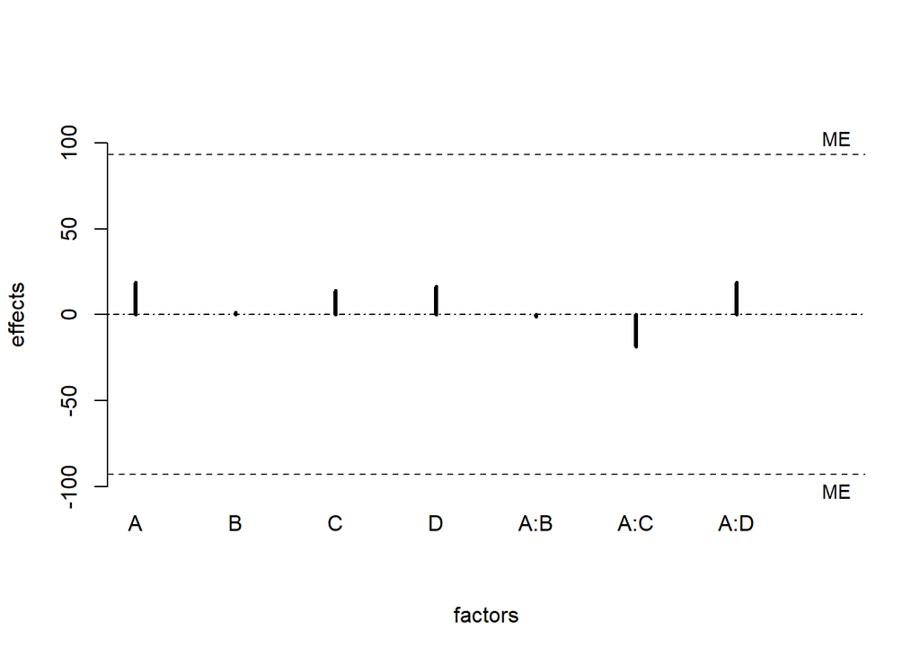

```
##     alpha       PSE        ME       SME
##   0.05000  24.75000  93.16205 222.95560
```

```r
BsMD::LenthPlot(fit1)
```